# Drumming chimps: Ratios statistics

Vesta Eleuteri & Jelle van der Werff

2024-10-22

# Introduction

This document accompanies the manuscript “Chimpanzee drumming shows rhythmicity and subspecies variation” Vesta Eleuteri et al. (2024).

# Preliminaries

## Load packages and data

```
## here() starts at /Users/jellevanderwerff/vesta_drumming_chimps
```

## Defining bins and coding ratios categories

```r
bins <- list(
  "1" = c(0, 1 / 4.25), # 1 / 4.5
  "2" = c(1 / 4.25, 1 / 3.75), # 1 / 4 > 1:3
  "3" = c(1 / 3.75, 1 / 3.25), # 1 / 3.5
  "4" = c(1 / 3.25, 1 / 2.75), # 1 / 3 > 1:2
  "5" = c(1 / 2.75, 1 / 2.25), # 1 / 2.5
  "6" = c(1 / 2.25, 1 - 1 / 2.25), # 1 / 2 > 1:1
  "7" = c(1 - 1 / 2.25, 1 - 1 / 2.75), # 1 - 1 / 2.5
  "8" = c(1 - 1 / 2.75, 1 - 1 / 3.25), # 1 - 1 / 3 > 2:1
  "9" = c(1 - 1 / 3.25, 1 - 1 / 3.75), # 1 - 1 / 3.5
  "10" = c(1 - 1 / 3.75, 1 - 1 / 4.25), # 1 - 1 / 4 > 3:1
  "11" = c(1 - 1 / 4.25, 1) # 1 - 1 / 4.5
)

breaks <- c(0, 1 / 4.25, 1 / 3.75, 1 / 3.25, 1 / 2.75, 1 / 2.25, 1 - 1 / 2.25, 1 - 1 / 2.75, 1 - 1 / 3.25, 1 - 1 / 3.75, 1 - 1 / 4.25, 1)

labels <- names(bins)

ratios$Bin <- cut(ratios$Ratio, breaks = breaks, labels = labels)
ratios.simulated$Bin <- cut(ratios.simulated$Ratio, breaks = breaks, labels = labels)
```

## Reordering/renaming variables etc.

```r
# Change levels order
ibis$Subspecies <- factor(ibis$Subspecies, levels = c("Western", "Eastern"))
ibis$Population <- factor(ibis$Population, levels = c("Fongoli", "Nimba", "Taï", "Gombe", "Kibale", "Budongo"))
ibis$Community <- factor(ibis$Community, levels = c(
  "Fongoli", "Tongbongbon", "Gahtoy", "East", "Middle", "North", "South",
  "Kasekela", "Kanyawara", "Sonso", "Waibira"
))

ratios$Subspecies <- factor(ratios$Subspecies, levels = c("Western", "Eastern"))
ratios$Population <- factor(ratios$Population, levels = c("Fongoli", "Nimba", "Taï", "Gombe", "Kibale", "Budongo"))
ratios$Community <- factor(ratios$Community, levels = c(
  "Fongoli", "Tongbongbon", "Gahtoy", "East", "Middle", "North", "South",
  "Kasekela", "Kanyawara", "Sonso", "Waibira"
))
```

# Descriptives (inter-hit interval and ratios)

```r
subspecies.table <- ddply(ibis, .(Subspecies), summarize,
  mean = mean(IBI_ms),
  median = median(IBI_ms),
  sd = sd(IBI_ms),
  min = min(IBI_ms),
  max = max(IBI_ms)
)
kable(subspecies.table, format = "html", caption = "Descriptives of inter-hit intervals (ms) by subspecies") %>%
  kable_styling("striped", full_width = FALSE) %>%
  column_spec(1, bold = TRUE) %>%
  column_spec(2:6, width = "100px")
```

Descriptives of inter-hit intervals (ms) by subspecies

| Subspecies | mean | median | sd | min | max |
| --- | --- | --- | --- | --- | --- |
| Western | 215.5910 | 173.088 | 186.0845 | 22.436 | 1726.775 |
| Eastern | 257.0149 | 159.390 | 273.5733 | 28.225 | 2151.772 |

```r
overall.table <- as.data.frame(ddply(ibis, .(), summarize,
  mean = mean(IBI_ms),
  median = median(IBI_ms),
  sd = sd(IBI_ms),
  min = min(IBI_ms),
  max = max(IBI_ms)
))
overall.table <- overall.table[, 2:6]

kable(overall.table, format = "html", caption = "Descriptives of inter-hit intervals (ms) overall") %>%
  kable_styling("striped", full_width = FALSE)
```

Descriptives of inter-hit intervals (ms) overall

| mean | median | sd | min | max |
| --- | --- | --- | --- | --- |
| 229.0263 | 169.352 | 219.1313 | 22.436 | 2151.772 |

# Main text: Statistics

## Introduction

Our main analysis relies on the method devised by Roeske et al. (2020), in which the relationships between adjacent inter-onset/inter-hit intervals (IOIs/IHIs) are described by the formula: $r_k = \frac{IOI_k}{IOI_k + IOI_{k+1}}$. This formula results in ratios $r_k$ that range from 0 to 1, where e.g. 0.5 indicates isochrony.

Recently, Jadoul et al. (2024) have highlighted a number of issues with the usual method of doing statistics with these ratios, and have improved the method as hitherto used. Our analysis takes into account these new insights.

Classically, the null hypothesis is that observed IOIs are distributed according to a random uniform distribution. However, the statistical tests that are generally used do not conform to this null hypothesis (Jadoul et al., 2024). According to Jadoul et al. (2024), the assumption of a uniformly random distribution of IOIs as the null-hypothesis means that the ratios are distributed according to the distribution plotted below. The exact shape of this distribution is dependent on the left and right bounds of the random uniform distribution used for sampling the IOIs. However, the shape will remain similar to the one plotted below.

As left (a) and right (b) bounds of the uniform distribution of IOIs, in our analysis we use the minimum observed IOI duration and the maximum observed IOI duration, respectively.

The dotted lines in the plot are the histogram bins, following Roeske et al. (2020), which represent the integer ratios 1:3 (bin centered around 0.25), 1:2 (bin centered around 0.33), 1:1 (isochrony; bin centered around 0.5), 2:1 (bin centered around 0.66), and 3:1 (bin centered around 0.75). The bins in between these integer ratios are the off-integer bins.

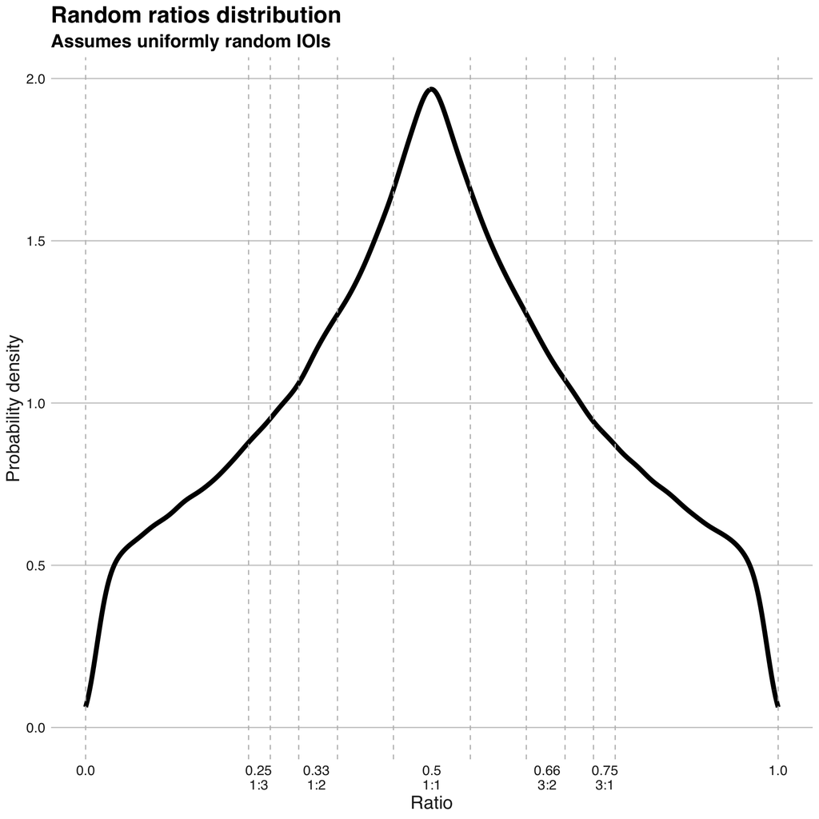

```r
ggplot(ratios.simulated, aes(x = Ratio)) +
  geom_density(linewidth = 2) +
  theme_drumming() +
  geom_vline(xintercept = breaks, linetype = "dashed", linewidth = 0.5, colour = "grey") +
  labs(x = "Ratio", y = "Probability density", title = "Random ratios distribution", subtitle = "Assumes uniformly random IOIs") +
  scale_x_continuous(
    breaks = c(0, 0.25, 0.3333, 0.5, 0.6666, 0.75, 1), limits = c(0, 1),
    labels = c("0.0", "0.25\n1:3", "0.33\n1:2", "0.5\n1:1", "0.66\n3:2", "0.75\n3:1", "1.0")
  )
```

We define the bins following Roeske et al. (2020):

```r
ratios.bins <- data.frame(bin = as.character(1:11))

ratios.bins$bin_left <- sapply(bins, function(x) x[1])
ratios.bins$bin_right <- sapply(bins, function(x) x[2])
ratios.bins$bin_name <- c("1/4.5", "1/4", "1/3.5", "1/3", "1/2.5", "1/2", "1 - 1/2", "1 - 1/3", "1 - 1/3.5", "1 - 1/4", "1 - 1/4.5")
ratios.bins$bin_alternative_name <- c("", "1:3", "", "1:2", "", "1:1", "", "2:1", "", "3:1", "")

kable(ratios.bins,
  format = "html", caption = "Bins definition", col.names =
    c("Bin", "Bin (left bound)", "Bin (right bound)", "Bin center", "Integer ratio")
) %>%
  kable_styling("striped", full_width = FALSE)
```

Bins definition

| Bin | Bin (left bound) | Bin (right bound) | Bin center | Integer ratio |
| --- | --- | --- | --- | --- |
| 1 | 0.0000000 | 0.2352941 | 1/4.5 |  |
| 2 | 0.2352941 | 0.2666667 | 1/4 | 1:3 |
| 3 | 0.2666667 | 0.3076923 | 1/3.5 |  |
| 4 | 0.3076923 | 0.3636364 | 1/3 | 1:2 |
| 5 | 0.3636364 | 0.4444444 | 1/2.5 |  |
| 6 | 0.4444444 | 0.5555556 | 1/2 | 1:1 |
| 7 | 0.5555556 | 0.6363636 | 1 - 1/2 |  |
| 8 | 0.6363636 | 0.6923077 | 1 - 1/3 | 2:1 |
| 9 | 0.6923077 | 0.7333333 | 1 - 1/3.5 |  |
| 10 | 0.7333333 | 0.7647059 | 1 - 1/4 | 3:1 |
| 11 | 0.7647059 | 1.0000000 | 1 - 1/4.5 |  |

Then, we count the number of observations in each bin.

```r
# Code off- and on-isochronous
ratios$On_off_isoc <- NA
ratios$On_off_isoc <- factor(ratios$On_off_isoc, levels = c("Off", "On", "Other"))
ratios$On_off_isoc <- "Other"
ratios$On_off_isoc[ratios$Bin %in% c(5, 7)] <- "Off"
ratios$On_off_isoc[ratios$Bin == 6] <- "On"

# Count
ratios.isoc.counts <- dplyr::summarize(dplyr::group_by(ratios, Subspecies, Population, Community, Com_indiv_code),
  On_isochronous = sum(On_off_isoc == "On"), Off_isochronous = sum(On_off_isoc == "Off"), Other = sum(On_off_isoc == "Other"), Total_obs = n()
)

kable(head(ratios.isoc.counts, 10),
  format = "html", align = "l",
  caption = "Counts of on- and off-isochronous drumming ratios (first 10 rows)",
  col.names = c(
    "Subspecies", "Population", "Community", "Community (Individual)", "On-isochronous count", "Off-isochronous count", "Other ratios count",
    "Total n ratios observed"
  )
) %>%
  kable_styling("striped", full_width = FALSE)
```

Counts of on- and off-isochronous drumming ratios (first 10 rows)

| Subspecies | Population | Community | Community (Individual) | On-isochronous count | Off-isochronous count | Other ratios count | Total n ratios observed |
| --- | --- | --- | --- | --- | --- | --- | --- |
| Western | Fongoli | Fongoli | Fongoli (DW) | 4 | 3 | 2 | 9 |
| Western | Fongoli | Fongoli | Fongoli (KL) | 15 | 3 | 10 | 28 |
| Western | Fongoli | Fongoli | Fongoli (LP) | 6 | 9 | 6 | 21 |
| Western | Fongoli | Fongoli | Fongoli (LX) | 5 | 4 | 6 | 15 |
| Western | Nimba | Tongbongbon | Tongbongbon (Male 1B) | 16 | 9 | 25 | 50 |
| Western | Nimba | Tongbongbon | Tongbongbon (Male 1D) | 10 | 11 | 26 | 47 |
| Western | Nimba | Tongbongbon | Tongbongbon (Male 1E) | 3 | 3 | 4 | 10 |
| Western | Nimba | Tongbongbon | Tongbongbon (Male 1G) | 10 | 10 | 16 | 36 |
| Western | Nimba | Gahtoy | Gahtoy (Male 2A) | 27 | 23 | 25 | 75 |
| Western | Nimba | Gahtoy | Gahtoy (Male 2C) | 2 | 5 | 5 | 12 |

## Plot of ratios distributions by subspecies

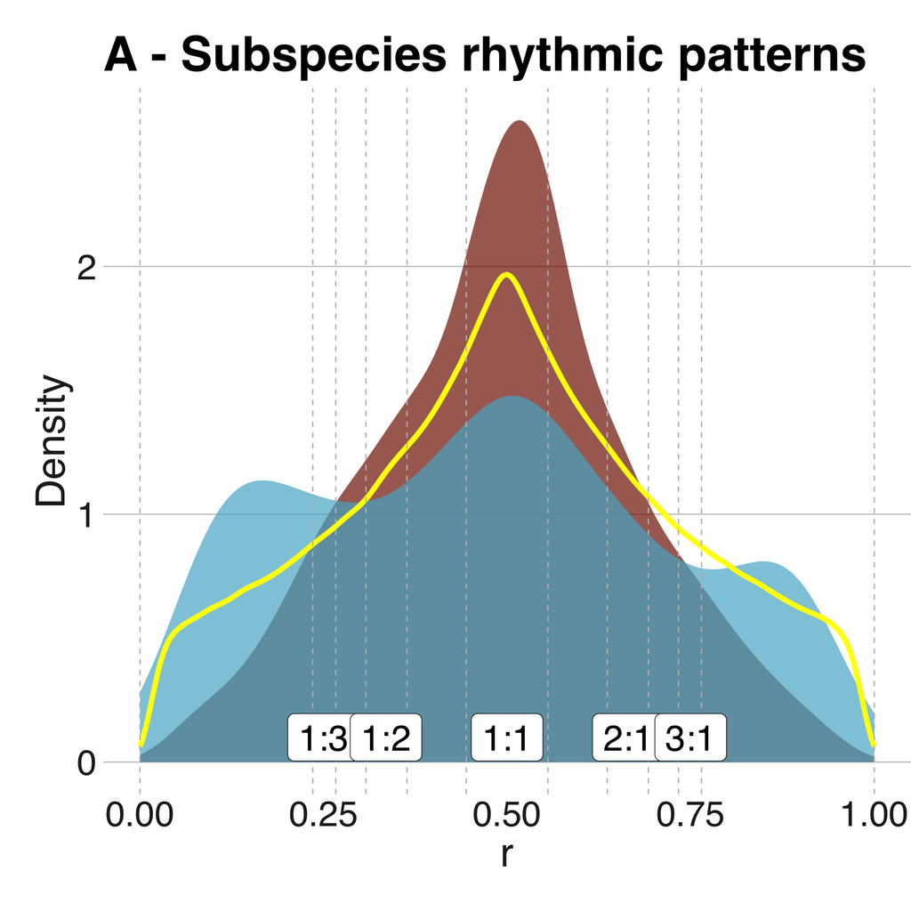

```r
labels <- as.data.frame(list(
  x = c(0.25, 0.335, 0.5, 0.665, 0.75),
  y = c(0.1, 0.1, 0.1, 0.1, 0.1),
  label = c("1:3", "1:2", "1:1", "2:1", "3:1"),
  size = c(4, 6, 10, 6, 4)
))

ggplot(ratios, aes(x = Ratio, fill = Subspecies)) +
  geom_density(linewidth = 0, alpha = 0.7) +
  geom_density(data = ratios.simulated, aes(x = Ratio), linewidth = 2, colour = "yellow", inherit.aes = FALSE, show.legend = FALSE) +
  theme_drumming() +
  geom_vline(xintercept = breaks, linetype = "dashed", linewidth = 0.5, colour = "grey") +
  labs(y = "Density", x = "r", fill = "", title = "A - Subspecies rhythmic patterns") +
  geom_label(data = labels, aes(x = x, y = y, label = label), size = 10, family = "Helvetica", inherit.aes = FALSE) +
  theme(
    plot.title = element_text(size = 38),
    axis.title.x = element_text(size = 32),
    axis.title.y = element_text(size = 32),
    axis.text.x = element_text(size = 28),
    axis.text.y = element_text(size = 28),
    legend.title = element_text(size = 32),
    legend.text = element_text(size = 32)
  ) +
  theme(plot.margin = margin(1, 0, 1, 1, "cm")) +
  guides(fill = "none")
```

```r
ggsave(here("plots", "integer_ratios_vs_random.png"), width = 26, height = 8)
ggsave(here("plots", "integer_ratios_vs_random.svg"), width = 26, height = 8)
```

## Statistics

We here test:

1. Whether the drumming ratios are randomly distributed (i.e. whether the observed ratios are different from a random distribution of ratios).
2. Whether the distributions of Eastern and Western are different from each other.
3. Whether there are more on-isochronous ratios than expected by chance.
4. Whether there is more isochrony in Eastern vs. Western.

### Is the drumming random? (drumming ratios vs. random distribution)

Here we answer the question: “Is the drumming random?” by comparing the distributions of observed ratios with the distribution of ratios as expected when IOIs are uniformly distributed (which we simulated above). We use Kolmogorov-Smirnov tests for the comparisons.

#### All observations (both East and West subspecies) vs. uniformly random

```r
ks.all <- ks.test(ratios$Ratio, ratios.simulated$Ratio, alternative = "two.sided")
ks.all
```

```
    Asymptotic two-sample Kolmogorov-Smirnov test

data:  ratios$Ratio and ratios.simulated$Ratio
D = 0.064645, p-value = 5.308e-07
alternative hypothesis: two-sided
```

**Across subspecies, the drumming is not random.**

#### Eastern chimps vs. uniformly random

```r
ks.eac <- ks.test(ratios$Ratio[ratios$Subspecies == "Eastern"], ratios.simulated$Ratio, alternative = "two.sided")
ks.eac
```

```
    Asymptotic two-sample Kolmogorov-Smirnov test

data:  ratios$Ratio[ratios$Subspecies == "Eastern"] and ratios.simulated$Ratio
D = 0.092049, p-value = 0.0001895
alternative hypothesis: two-sided
```

**For Eastern chimps, the drumming is not random.**

#### Western chimps vs. uniformly random

```r
ks.wac <- ks.test(ratios$Ratio[ratios$Subspecies == "Western"], ratios.simulated$Ratio, alternative = "two.sided")
ks.wac
```

```
    Asymptotic two-sample Kolmogorov-Smirnov test

data:  ratios$Ratio[ratios$Subspecies == "Western"] and ratios.simulated$Ratio
D = 0.088117, p-value = 5.757e-09
alternative hypothesis: two-sided
```

**For Western chimps, the drumming is not random.**

### Are the distributions of Eastern and Western different from each other?

```r
ks.eac.vs.wac <- ks.test(ratios$Ratio[ratios$Subspecies == "Eastern"], ratios$Ratio[ratios$Subspecies == "Western"], alternative = "two.sided")
ks.eac.vs.wac
```

```
    Asymptotic two-sample Kolmogorov-Smirnov test

data:  ratios$Ratio[ratios$Subspecies == "Eastern"] and ratios$Ratio[ratios$Subspecies == "Western"]
D = 0.14976, p-value = 7.184e-08
alternative hypothesis: two-sided
```

**The distributions of Eastern and Western are different from each other.**

### Are there more on-isochronous ratios than expected by chance?

Here we compare the proportion of on-isochronous ratios to the proportion expected by chance (assuming uniformly random IOIs).

We do so by subtracting the surface area of the isochronous bin from each empirical probability (i.e. $\frac{\textrm{number of isochronous observations}}{\textrm{total number of observations}}$) per individual.

Then we test (using a one-sample Wilcoxon signed-rank test) whether those values are different from 0 (where 0 indicates chance level).

The surface area of the isochronous bin is here calculated using the formula provided by Jadoul et al. (2024):

$$\frac{1}{2} - \frac{(4b - 5a)^2}{40 (b -
a)^2}$$

```r
# Calculate the surface area of the isochronous bin using the formula from Jadoul et al. (2024)
a <- min(ibis$IBI_ms)
b <- max(ibis$IBI_ms)
surface_area_isochronous <- ((1 / 2) - (((4 * b - 5 * a)^2) / (40 * (b - a)^2)))

# Multiply by two (there's one bin on each side of 0.5 when using this formula)
surface_area_isochronous <- surface_area_isochronous * 2 # 0.2042091

# Subtract surface area of isochronous bin from empirical probabilities
ratios.isoc.counts$Isoc_prob <- ratios.isoc.counts$On_isochronous / ratios.isoc.counts$Total_obs
ratios.isoc.counts$Isoc_prob_normalized <- ratios.isoc.counts$Isoc_prob - surface_area_isochronous
```

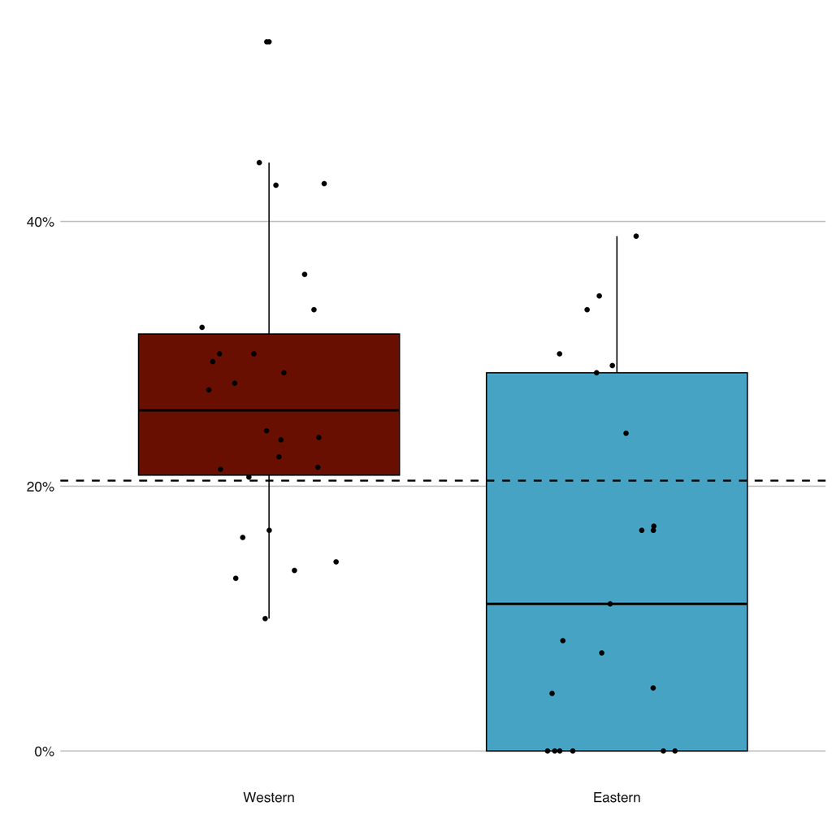

```r
ggplot(ratios.isoc.counts, aes(y = Isoc_prob * 100, x = Subspecies, fill = Subspecies)) +
  geom_boxplot(colour = "black", show.legend = FALSE) +
  geom_jitter(width = 0.2, height = 0, show.legend = FALSE) +
  theme_drumming() +
  labs(
    y = "", x = "",
  ) +
  geom_hline(yintercept = surface_area_isochronous * 100, linetype = "dashed", linewidth = 0.8) +
  scale_y_continuous(labels = scales::percent_format(scale = 1))
```

```r
ggsave(here("plots", "isochronous_ratios_vs_random.svg"), width = 4, height = 4)
ggsave(here("plots", "isochronous_ratios_vs_random.png"), width = 4, height = 4)
```

#### All observations

```r
isoc.vs.random.wsrt.all <- wilcox.test(ratios.isoc.counts$Isoc_prob_normalized, alternative = "two.sided")
isoc.vs.random.wsrt.all
```

```
    Wilcoxon signed rank test with continuity correction

data:  ratios.isoc.counts$Isoc_prob_normalized
V = 606, p-value = 0.6604
alternative hypothesis: true location is not equal to 0
```

```r
print(paste("Median for all chimps:", median(ratios.isoc.counts$Isoc_prob_normalized)))
```

```
[1] "Median for all chimps: 0.0180131260429715"
```

**Across subspecies, there are not more on-isochronous ratios than expected by chance.**

#### Eastern chimps

```r
isoc.vs.random.wsrt.eac <- wilcox.test(ratios.isoc.counts$Isoc_prob_normalized[ratios.isoc.counts$Subspecies == "Eastern"], alternative = "two.sided") # Significant
isoc.vs.random.wsrt.eac
```

```
    Wilcoxon signed rank test with continuity correction

data:  ratios.isoc.counts$Isoc_prob_normalized[ratios.isoc.counts$Subspecies == "Eastern"]
V = 58, p-value = 0.04697
alternative hypothesis: true location is not equal to 0
```

```r
print(paste("Median for Eastern:", median(ratios.isoc.counts$Isoc_prob_normalized[ratios.isoc.counts$Subspecies == "Eastern"])))
```

```
[1] "Median for Eastern: -0.0930979850681397"
```

**In Eastern chimps, there are significantly *fewer* on-isochronous ratios than expected by chance.**

#### Western chimps

```r
isoc.vs.random.wsrt.wac <- wilcox.test(ratios.isoc.counts$Isoc_prob_normalized[ratios.isoc.counts$Subspecies == "Western"], alternative = "two.sided") # Significant
isoc.vs.random.wsrt.wac
```

```
    Wilcoxon signed rank test with continuity correction

data:  ratios.isoc.counts$Isoc_prob_normalized[ratios.isoc.counts$Subspecies == "Western"]
V = 281, p-value = 0.007656
alternative hypothesis: true location is not equal to 0
```

```r
print(paste("Median for Western:", median(ratios.isoc.counts$Isoc_prob_normalized[ratios.isoc.counts$Subspecies == "Western"])))
```

```
[1] "Median for Western: 0.0531222821198695"
```

**In Western chimps, there are significantly *more* on-isochronous ratios than expected by chance.**

### Is there more isochrony in Eastern vs. Western?

Here we compare the empirical probabilities (i.e. $\frac{\textrm{number of isochronous observations}}{\textrm{total number of observations}}$) of on-isochronous ratios between Eastern and Western chimps using a Wilcoxon rank-sum test.

```r
wilcox.test(
  ratios.isoc.counts$Isoc_prob[ratios.isoc.counts$Subspecies == "Western"],
  ratios.isoc.counts$Isoc_prob[ratios.isoc.counts$Subspecies == "Eastern"]
)
```

```
    Wilcoxon rank sum test with continuity correction

data:  ratios.isoc.counts$Isoc_prob[ratios.isoc.counts$Subspecies == "Western"] and ratios.isoc.counts$Isoc_prob[ratios.isoc.counts$Subspecies == "Eastern"]
W = 403, p-value = 0.005526
alternative hypothesis: true location shift is not equal to 0
```

```r
print(paste("Median for East:", median(ratios.isoc.counts$Isoc_prob[ratios.isoc.counts$Subspecies == "Eastern"])))
```

```
[1] "Median for East: 0.111111111111111"
```

```r
print(paste("Median for West:", median(ratios.isoc.counts$Isoc_prob[ratios.isoc.counts$Subspecies == "Western"])))
```

```
[1] "Median for West: 0.25733137829912"
```

**Yes, there are more on-isochronous ratios in Western than in Eastern.**

# Supplement: Statistics (>= 5 hits)

## Preparations

We subset the data to only include drumming bouts with 5 or more hits.

```r
ratios.5plushits <- ratios
ratios.5plushits <- ratios.5plushits %>%
  group_by(Drumming_bout) %>%
  filter(n() >= 3) %>% # remove drums < 3 ratios.5plushits (4 IBIs/5 beats)
  group_by(Com_indiv_code) %>% # remove individuals with <3 drums
  filter(n_distinct(Drumming_bout) >= 3) %>%
  group_by(Community) %>% # remove communities with <1 individual
  filter(n_distinct(Individual) > 1) %>%
  ungroup()
```

### Counting the number of empirical observations in each bin

Below, we count the number of empirical observations in each bin for bouts with 5 hits or more.

```r
# Code off- and on-isochronous
ratios.5plushits$On_off_isoc <- NA
ratios.5plushits$On_off_isoc <- factor(ratios.5plushits$On_off_isoc, levels = c("Off", "On", "Other"))
ratios.5plushits$On_off_isoc <- "Other"
ratios.5plushits$On_off_isoc[ratios.5plushits$Bin %in% c(5, 7)] <- "Off"
ratios.5plushits$On_off_isoc[ratios.5plushits$Bin == 6] <- "On"

# Count
ratios.5plushits.isoc.counts <- dplyr::summarize(dplyr::group_by(ratios.5plushits, Subspecies, Population, Community, Com_indiv_code),
  On_isochronous = sum(On_off_isoc == "On"), Off_isochronous = sum(On_off_isoc == "Off"), Other = sum(On_off_isoc == "Other"), Total_obs = n()
)
```

## Statistics

### Is the drumming random? (drumming ratios vs. random distribution)

Here we answer the question: “Is the drumming random?” by comparing the distributions of observed ratios with the distribution of ratios as expected when IOIs are uniformly distributed. We use the Kolmogorov-Smirnov test for this purpose.

#### All observations (both East and West subspecies) vs. uniformly random

```r
ks.all <- ks.test(ratios.5plushits$Ratio, ratios.simulated$Ratio, alternative = "two.sided")
ks.all
```

```
    Asymptotic two-sample Kolmogorov-Smirnov test

data:  ratios.5plushits$Ratio and ratios.simulated$Ratio
D = 0.070406, p-value = 2.757e-06
alternative hypothesis: two-sided
```

**Across subspecies and looking only at drumming bouts with 5 or more hits, the drumming is not random.**

#### Eastern chimps vs. uniformly random

```r
ks.eac <- ks.test(ratios.5plushits$Ratio[ratios.5plushits$Subspecies == "Eastern"], ratios.simulated$Ratio, alternative = "two.sided")
ks.eac
```

```
    Asymptotic two-sample Kolmogorov-Smirnov test

data:  ratios.5plushits$Ratio[ratios.5plushits$Subspecies == "Eastern"] and ratios.simulated$Ratio
D = 0.043575, p-value = 0.5161
alternative hypothesis: two-sided
```

**For Eastern chimps, looking only at drumming bouts with 5 or more hits, the drumming is random.**

#### Western chimps vs. uniformly random

```r
ks.wac <- ks.test(ratios.5plushits$Ratio[ratios.5plushits$Subspecies == "Western"], ratios.simulated$Ratio, alternative = "two.sided")
ks.wac
```

```
    Asymptotic two-sample Kolmogorov-Smirnov test

data:  ratios.5plushits$Ratio[ratios.5plushits$Subspecies == "Western"] and ratios.simulated$Ratio
D = 0.084779, p-value = 9.903e-07
alternative hypothesis: two-sided
```

**For Western chimps, looking only at drumming bouts with 5 or more hits, the drumming is not random.**

### Are the distributions of Eastern and Western different from each other?

```r
ks.eac.vs.wac <- ks.test(ratios.5plushits$Ratio[ratios.5plushits$Subspecies == "Eastern"],
  ratios.5plushits$Ratio[ratios.5plushits$Subspecies == "Western"], alternative = "two.sided")
ks.eac.vs.wac
```

```
    Asymptotic two-sample Kolmogorov-Smirnov test

data:  ratios.5plushits$Ratio[ratios.5plushits$Subspecies == "Eastern"] and ratios.5plushits$Ratio[ratios.5plushits$Subspecies == "Western"]
D = 0.085806, p-value = 0.04278
alternative hypothesis: two-sided
```

**The distributions of Eastern and Western are different from each other, also when looking only at drumming bouts with 5 or more hits.**

### Are there more on-isochronous ratios than expected by chance?

Here we compare the proportion of on-isochronous ratios to the proportion expected by chance (assuming uniformly random IOIs).

We do so by subtracting the surface area of the isochronous bin from each empirical probability (i.e. $\frac{\textrm{number of isochronous observations}}{\textrm{total number of observations}}$) per individual.

Then we test (using a one-sample Wilcoxon signed-rank test) whether those values are different from 0 (where 0 indicates chance level).

The surface area of the isochronous bin is here calculated using the formula provided by Jadoul et al. (2024):

$$\frac{1}{2} - \frac{(4b - 5a)^2}{40 (b -
a)^2}$$

```r
# Calculate the surface area of the isochronous bin using the formula from Jadoul et al. (2024)
a <- min(ibis$IBI_ms)
b <- max(ibis$IBI_ms)
surface_area_isochronous <- ((1 / 2) - (((4 * b - 5 * a)^2) / (40 * (b - a)^2)))

# Multiply by two (there's one bin on each side of 0.5 when using this formula)
surface_area_isochronous <- surface_area_isochronous * 2 # 0.2042091

# Subtract surface area of isochronous bin from empirical probabilities
ratios.5plushits.isoc.counts$Isoc_prob <- ratios.5plushits.isoc.counts$On_isochronous / ratios.5plushits.isoc.counts$Total_obs
ratios.5plushits.isoc.counts$Isoc_prob_normalized <- ratios.5plushits.isoc.counts$Isoc_prob - surface_area_isochronous
```

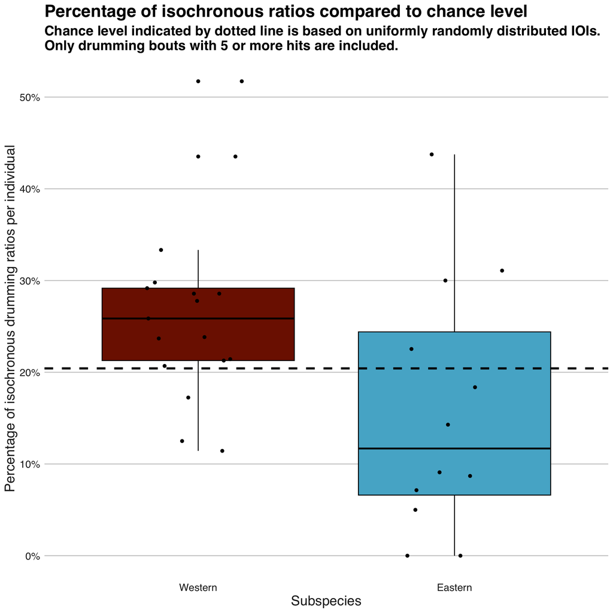

```r
ggplot(ratios.5plushits.isoc.counts, aes(y = Isoc_prob * 100, x = Subspecies, fill = Subspecies)) +
  geom_boxplot(colour = "black", show.legend = FALSE) +
  geom_jitter(width = 0.2, height = 0, show.legend = FALSE) +
  theme_drumming() +
  labs(
    y = "Percentage of isochronous drumming ratios per individual", x = "Subspecies",
    title = "Percentage of isochronous ratios compared to chance level", subtitle = "Chance level indicated by dotted line is based on uniformly randomly distributed IOIs.\nOnly drumming bouts with 5 or more hits are included.",
  ) +
  geom_hline(yintercept = surface_area_isochronous * 100, linetype = "dashed", linewidth = 1.2) +
  scale_y_continuous(labels = scales::percent_format(scale = 1))
```

#### All observations

```r
isoc.vs.random.wsrt.all <- wilcox.test(ratios.5plushits.isoc.counts$Isoc_prob_normalized, alternative = "two.sided")
isoc.vs.random.wsrt.all
```

```
    Wilcoxon signed rank test with continuity correction

data:  ratios.5plushits.isoc.counts$Isoc_prob_normalized
V = 248, p-value = 0.5165
alternative hypothesis: true location is not equal to 0
```

```r
print(paste("Median for all chimps:", median(ratios.5plushits.isoc.counts$Isoc_prob_normalized)))
```

```
[1] "Median for all chimps: 0.0211430164968056"
```

**Across subspecies, there are not more on-isochronous ratios than expected by chance, also when looking only at drumming bouts with 5 or more hits.**

#### Eastern chimps

```r
isoc.vs.random.wsrt.eac <- wilcox.test(ratios.5plushits.isoc.counts$Isoc_prob_normalized[ratios.5plushits.isoc.counts$Subspecies == "Eastern"], alternative = "two.sided") # Significant
isoc.vs.random.wsrt.eac
```

```
    Wilcoxon signed rank test with continuity correction

data:  ratios.5plushits.isoc.counts$Isoc_prob_normalized[ratios.5plushits.isoc.counts$Subspecies == "Eastern"]
V = 23, p-value = 0.2238
alternative hypothesis: true location is not equal to 0
```

```r
print(paste("Median for Eastern:", median(ratios.5plushits.isoc.counts$Isoc_prob_normalized[ratios.5plushits.isoc.counts$Subspecies == "Eastern"])))
```

```
[1] "Median for Eastern: -0.0873259792961339"
```

**In Eastern chimps, when looking only at drumming bouts with 5 or more events, there are not significantly more or fewer on-isochronous ratios than expected by chance.**

#### Western chimps

```r
isoc.vs.random.wsrt.wac <- wilcox.test(ratios.5plushits.isoc.counts$Isoc_prob_normalized[ratios.5plushits.isoc.counts$Subspecies == "Western"], alternative = "two.sided") # Significant
isoc.vs.random.wsrt.wac
```

```
    Wilcoxon signed rank test with continuity correction

data:  ratios.5plushits.isoc.counts$Isoc_prob_normalized[ratios.5plushits.isoc.counts$Subspecies == "Western"]
V = 127, p-value = 0.01792
alternative hypothesis: true location is not equal to 0
```

```r
print(paste("Median for Western:", median(ratios.5plushits.isoc.counts$Isoc_prob_normalized[ratios.5plushits.isoc.counts$Subspecies == "Western"])))
```

```
[1] "Median for Western: 0.0544115934759217"
```

**In Western chimps, there are significantly *more* on-isochronous ratios than expected by chance, also when only looking at drumming bouts with 5 or more events.**

### Is there more isochrony in Eastern vs. Western?

Here we compare the empirical probabilities (i.e. $\frac{\textrm{number of isochronous observations}}{\textrm{total number of observations}}$) of on-isochronous ratios between Eastern and Western chimps using a Wilcoxon rank-sum test.

```r
wilcox.test(
  ratios.5plushits.isoc.counts$Isoc_prob[ratios.5plushits.isoc.counts$Subspecies == "Western"],
  ratios.5plushits.isoc.counts$Isoc_prob[ratios.5plushits.isoc.counts$Subspecies == "Eastern"]
)
```

```
    Wilcoxon rank sum test with continuity correction

data:  ratios.5plushits.isoc.counts$Isoc_prob[ratios.5plushits.isoc.counts$Subspecies == "Western"] and ratios.5plushits.isoc.counts$Isoc_prob[ratios.5plushits.isoc.counts$Subspecies == "Eastern"]
W = 149, p-value = 0.03944
alternative hypothesis: true location shift is not equal to 0
```

**Yes, there are more on-isochronous ratios in Western than in Eastern chimps, also when looking only at drumming bouts with 5 or more hits.**

# Supplement: Statistics (old method using bin width normalization)

## Introduction

We here use the method as has been used until now in the literature, which, due to the normalization procedure (i.e. dividing by the bin *width* rather than the bin *surface area*), assumes exponentially distributed IOIs resulting from a Poisson point-process (Jadoul et al., 2024).

## Define bins, bin widths, etc.

```r
ratios.normalization <- data.frame(bin = as.character(1:11))
ratios.normalization$surface_area <- NA
for (i in 1:11) {
  bin <- bins[[as.character(i)]]
  ratios.normalization$surface_area[ratios.normalization$bin == as.character(i)] <- length(ratios.simulated$Ratio[ratios.simulated$Ratio >= bin[1] &
    ratios.simulated$Ratio < bin[2]]) / length(ratios.simulated$Ratio)
}
ratios.normalization$bin_left <- sapply(bins, function(x) x[1])
ratios.normalization$bin_right <- sapply(bins, function(x) x[2])
ratios.normalization$bin_size <- ratios.normalization$bin_right - ratios.normalization$bin_left
ratios.normalization$bin_name <- c("1/4.5", "1/4", "1/3.5", "1/3", "1/2.5", "1/2", "1 - 1/2", "1 - 1/3", "1 - 1/3.5", "1 - 1/4", "1 - 1/4.5")
ratios.normalization$bin_alternative_name <- c("", "1:3", "", "1:2", "", "1:1", "", "2:1", "", "3:1", "")
```

## Counting the number of empirical observations in each bin and normalize

Below, we count the number of empirical observations in each bin and normalize them by dividing by the *bin width*.

```r
# Code off- and on-isochronous
ratios$On_off_isoc <- NA
ratios$On_off_isoc <- factor(ratios$On_off_isoc, levels = c("Off", "On", "Other"))
ratios$On_off_isoc <- "Other"
ratios$On_off_isoc[ratios$Bin %in% c(5, 7)] <- "Off"
ratios$On_off_isoc[ratios$Bin == 6] <- "On"

# Count
ratios.isoc.counts.poiss <- dplyr::summarize(dplyr::group_by(ratios, Subspecies, Population, Community, Com_indiv_code),
  On_isochronous = sum(On_off_isoc == "On"), Off_isochronous = sum(On_off_isoc == "Off"), Other = sum(On_off_isoc == "Other"), Total_obs = n()
)

# Normalize
ratios.isoc.counts.poiss$On_isochronous_norm <- ratios.isoc.counts.poiss$On_isochronous / (ratios.normalization$bin_size[6] * ratios.isoc.counts$Total_obs)
ratios.isoc.counts.poiss$Off_isochronous_norm <- ratios.isoc.counts.poiss$Off_isochronous / ((ratios.normalization$bin_size[5] + ratios.normalization$bin_size[7]) * ratios.isoc.counts$Total_obs)
ratios.isoc.counts.poiss$Other_norm <- ratios.isoc.counts.poiss$Other / ((1 - sum(ratios.normalization$bin_size[5:7])) * ratios.isoc.counts$Total_obs)
```

The values in the normalized columns represent how much more above chance level the observed counts are. For example, a value of 1.0 means that the observed counts are as expected by chance, a value of 2.0 means that the observed counts are twice what was expected by chance, and so on.

## Statistics

### Is the drumming random? (drumming ratios vs. random distribution)

Here we answer the question: “Is the drumming random?” by comparing the distributions of observed ratios with the distribution of ratios as expected when IOIs are exponentially distributed (i.e. resulting from a Poisson point-process). We use the Kolmogorov-Smirnov test for this purpose.

#### All observations (both East and West subspecies) vs. Poisson-assumed

```r
ks.all.poiss <- ks.test(ratios$Ratio, "punif")
ks.all.poiss
```

```
    Asymptotic one-sample Kolmogorov-Smirnov test

data:  ratios$Ratio
D = 0.15463, p-value < 2.2e-16
alternative hypothesis: two-sided
```

*Across subspecies, the drumming ratios are not uniformly randomly distributed.*

#### Eastern chimps vs. Poisson-assumed

```r
ks.eac.poiss <- ks.test(ratios$Ratio[ratios$Subspecies == "Eastern"], "punif")
ks.eac.poiss
```

```
    Asymptotic one-sample Kolmogorov-Smirnov test

data:  ratios$Ratio[ratios$Subspecies == "Eastern"]
D = 0.10079, p-value = 2.982e-05
alternative hypothesis: two-sided
```

*Eastern chimps’ drumming ratios are not uniformly randomly distributed.*

#### Western chimps vs. Poisson-assumed

```r
ks.wac.poiss <- ks.test(ratios$Ratio[ratios$Subspecies == "Western"], "punif")
ks.wac.poiss
```

```
    Asymptotic one-sample Kolmogorov-Smirnov test

data:  ratios$Ratio[ratios$Subspecies == "Western"]
D = 0.17843, p-value < 2.2e-16
alternative hypothesis: two-sided
```

*Western chimps’ drumming ratios are not uniformly randomly distributed.*

#### Are the distributions of Eastern and Western different from each other?

This of course does not depend on the null hypothesis of how the IOIs are distributed but is included here for completeness (as also done in the previous section).

```r
ks.eac.vs.wac.poiss <- ks.test(ratios$Ratio[ratios$Subspecies == "Eastern"], ratios$Ratio[ratios$Subspecies == "Western"])
ks.eac.vs.wac.poiss
```

```
    Asymptotic two-sample Kolmogorov-Smirnov test

data:  ratios$Ratio[ratios$Subspecies == "Eastern"] and ratios$Ratio[ratios$Subspecies == "Western"]
D = 0.14976, p-value = 7.184e-08
alternative hypothesis: two-sided
```

*The distributions of Eastern and Western are different from each other.*

### More on-isochronous vs. off-isochronous?

Here we use the the classic method of comparing the number of on-isochronous vs. off-isochronous ratios, using the (until now common method for) normalization such that we divide by the *bin width* (which assumes exponentially distributed IOIs resulting from a Poissant point-process).

#### All observations

```r
# Paired Wilcoxon test
wilcox.test(ratios.isoc.counts.poiss$On_isochronous_norm, ratios.isoc.counts.poiss$Off_isochronous_norm, paired = TRUE)
```

```
    Wilcoxon signed rank test with continuity correction

data:  ratios.isoc.counts.poiss$On_isochronous_norm and ratios.isoc.counts.poiss$Off_isochronous_norm
V = 751, p-value = 0.002866
alternative hypothesis: true location shift is not equal to 0
```

*Using the standard normalization procedure (i.e. dividing by bin width) we find that there are more on-isochronous ratios than off-isochronous ratios across subspecies.*

#### Eastern

```r
wilcox.test(ratios.isoc.counts.poiss$On_isochronous_norm[ratios.isoc.counts.poiss$Subspecies == "Eastern"],
  ratios.isoc.counts.poiss$Off_isochronous_norm[ratios.isoc.counts.poiss$Subspecies == "Eastern"],
  paired = TRUE
)
```

```
    Wilcoxon signed rank test with continuity correction

data:  ratios.isoc.counts.poiss$On_isochronous_norm[ratios.isoc.counts.poiss$Subspecies == "Eastern"] and ratios.isoc.counts.poiss$Off_isochronous_norm[ratios.isoc.counts.poiss$Subspecies == "Eastern"]
V = 118, p-value = 0.1634
alternative hypothesis: true location shift is not equal to 0
```

*Using the standard normalization procedure (i.e. dividing by bin width) we find that there are not more on-isochronous ratios than off-isochronous ratios in Eastern chimps.*

#### Western

```r
wilcox.test(ratios.isoc.counts.poiss$On_isochronous_norm[ratios.isoc.counts.poiss$Subspecies == "Western"],
  ratios.isoc.counts.poiss$Off_isochronous_norm[ratios.isoc.counts.poiss$Subspecies == "Western"],
  paired = TRUE
)
```

```
    Wilcoxon signed rank exact test

data:  ratios.isoc.counts.poiss$On_isochronous_norm[ratios.isoc.counts.poiss$Subspecies == "Western"] and ratios.isoc.counts.poiss$Off_isochronous_norm[ratios.isoc.counts.poiss$Subspecies == "Western"]
V = 279, p-value = 0.007291
alternative hypothesis: true location shift is not equal to 0
```

#### Are there more on-isochronous ratios in Western than in Eastern?

```r
wilcox.test(
  ratios.isoc.counts.poiss$On_isochronous_norm[ratios.isoc.counts.poiss$Subspecies == "Western"],
  ratios.isoc.counts.poiss$On_isochronous_norm[ratios.isoc.counts.poiss$Subspecies == "Eastern"]
)
```

```
    Wilcoxon rank sum test with continuity correction

data:  ratios.isoc.counts.poiss$On_isochronous_norm[ratios.isoc.counts.poiss$Subspecies == "Western"] and ratios.isoc.counts.poiss$On_isochronous_norm[ratios.isoc.counts.poiss$Subspecies == "Eastern"]
W = 403, p-value = 0.005526
alternative hypothesis: true location shift is not equal to 0
```

```r
print(paste("Median for East:", median(ratios.isoc.counts.poiss$On_isochronous_norm[ratios.isoc.counts.poiss$Subspecies == "Eastern"])))
```

```
[1] "Median for East: 1"
```

```r
print(paste("Median for West:", median(ratios.isoc.counts.poiss$On_isochronous_norm[ratios.isoc.counts.poiss$Subspecies == "Western"])))
```

```
[1] "Median for West: 2.31598240469208"
```

*Using the standard normalization procedure (i.e. dividing by bin width) we find that there are more on-isochronous ratios in Western chimpanzees than in Eastern chimpanzees.*

# References

Jadoul, Y., Tufarelli, T., Coissac, C., Gamba, M., & Ravignani, A. (2024). *Hidden assumptions of integer ratio analyses in bioacoustics and music* [Submitted for Publication].

Roeske, T. C., Tchernichovski, O., Poeppel, D., & Jacoby, N. (2020). Categorical Rhythms Are Shared between Songbirds and Humans. *Current Biology*, *30*(18), 3544–3555.e6. https://doi.org/10.1016/j.cub.2020.06.072

Vesta Eleuteri, Jelle van der Werff, Wytse Wilhelm, Adrian Soldati, Josep Call, Catherine Crockford, Nisarg Desai, Pawel Fedurek, Kirsty E. Graham, Kathelijne Koops, Maegan Fitzgerald, Liran Samuni, Katie Slocombe, Jill Pruetz, Angela Stoeger, Michael Wilson, Roman Wittig, Klaus Zuberbühler, Andrea Ravignani, & Catherine Hobaiter. (2024). *Chimpanzee drumming shows rhythmicity and subspecies variation* [Submitted for Publication].